# Prediction of urban-to-rural TB prevalence

### Libraries

Load the required packages

```r
library(tidyverse)
library(here)
library(brms)
library(tidybayes)
library(scales)
library(treemapify)
library(DT)
```

### Functions

1. Draw posterior samples from the timeEffects Model (i.e. meta-regression model, with time covariate, and random-effects for study ID and country)

```r
sample_posterior_time_model <- function(data, model, years, reformula){

  #Make a prediction dataset

  year_z <- years - 2011

  nd <- data %>%
    distinct(WHO.region, study.country) %>%
    mutate(logOR_se = 1) %>%
    crossing(year_z)

  #Add the predicted draws of urban-to-rural prevalence ratio
  ur_draws <- add_epred_draws({model},
                              newdata = nd,
                              re_formula = reformula) %>%
    mutate(urRatio = exp(.epred))

  #Summarise the urban-to-rural prevalence ratio by taking the mean and 95% CrI
  ur_sum <- ur_draws %>%
    ungroup() %>%
    group_by(year_z, study.country) %>%
    mean_qi(urRatio)

  #put output into a list
  ur_time_out <- lst(
    ur_draws = ur_draws,
    ur_sum = ur_sum)

}
```

2. Organise the population deonominator data to align with the model predictions

```r
organise_pop_denominators <- function(modelling_data, population_data, urban_data, years) {

  # 1) study countries
  study.countries <- modelling_data %>%
    distinct(study.country) %>%
    pull(study.country)

  # 2) harmonise country names
  harmonise_country <- function(x) {
    case_when(
      x == "Viet Nam" ~ "Vietnam",
      x == "Gambia, The" ~ "Gambia",
      x == "Lao PDR" ~ "Laos",
      x == "Korea, Dem. People's Rep." ~ "North Korea",
      TRUE ~ x
    )
  }

  population_data <- population_data %>%
    mutate(study.country = harmonise_country(Country_Name))

  urban_data <- urban_data %>%
    mutate(study.country = harmonise_country(`Country Name`))

  # 3) pivot population data to long
  pops_df <- population_data %>%
    filter(study.country %in% study.countries) %>%
    select(study.country, any_of(as.character(years))) %>%
    pivot_longer(
      cols = -study.country,
      names_to = "year",
      values_to = "population"
    ) %>%
    mutate(
      year = as.integer(year),
      population = as.numeric(population)
    )

  # 4) pivot urban data to long
  urban_df <- urban_data %>%
    filter(study.country %in% study.countries) %>%
    select(study.country, any_of(as.character(years))) %>%
    pivot_longer(
      cols = -study.country,
      names_to = "year",
      values_to = "urban_perc"
    ) %>%
    mutate(
      year = as.integer(year),
      urban_perc = as.numeric(urban_perc),
      urban_prop = urban_perc / 100
    )

  # 5) join population and urban proportions
  population_out <- left_join(pops_df, urban_df, by = c("study.country", "year")) %>%
    mutate(
      rural_perc = 100 - urban_perc,
      rural_prop = 1 - urban_prop,
      urban_population = population * urban_prop,
      rural_population = population * rural_prop,
      year_z = year - 2011
    ) %>%
    arrange(study.country, year)

  return(population_out)
}
```

3. WHO TB burden data

```r
get_who_tb_burden <- function(modelling_data, who_tb_data, years) {

  # 1) study countries from modelling data
  study.countries <- modelling_data %>%
    distinct(study.country) %>%
    pull(study.country)

  # 2) get the WHO TB data, tidy country names, filter to selected countries & years
  who_tb_estimates <- who_tb_data %>%
    select(
      study.country = country,
      year,
      e_inc_100k:e_inc_num_hi,
      c_cdr:c_cdr_hi
    ) %>%
    filter(year %in% years) %>%
    mutate(
      year = as.integer(year),
      study.country = case_when(
        study.country == "Viet Nam" ~ "Vietnam",
        study.country == "United Republic of Tanzania" ~ "Tanzania",
        study.country == "Lao People's Democratic Republic" ~ "Laos",
        study.country == "Democratic People's Republic of Korea" ~ "North Korea",
        TRUE ~ study.country
      )
    ) %>%
    filter(study.country %in% study.countries) %>%
    arrange(study.country, year) %>%
    mutate(year_z = year - 2011,
           year = as.integer(year))

  return(who_tb_estimates)
}
```

4. Join the the population data to the WHO data

```r
join_population_with_who <- function(population_data, who_data) {
  population_and_who <- left_join(
    population_data,
    who_data,
    by = c("study.country", "year", "year_z")
  )

  return(population_and_who)
}
```

5. Multivariable model of WHO TB incidence and CDR data for subsequently estimating prevalence

Convert incidence to prevalence using the steady-state identity:

prevalence ≈ incidence (cases/year) × average duration of disease (years)

For the duration, define an effective duration that averages over untreated and treated trajectories:

D_eff = (1−c) D_untreated + c x D_treated

Where c is the fraction of incident cases that are treated (e.g. approximated by case detection ratio). Following Tiemersma et al. untreated TB lasts aronud ~3 years on average; we will also assume that treated TB lasts for 6months.

- D_treated ≈ 0.5 years
- D_untreated ≈ 3 years
- c ≈ case detection rate

```r
estimate_prevalence <- function(input_data,
                               d_treated = 0.5,               # default treated duration in years
                               years,
                               duration_mode = c("fixed", "mixture"),
                               sample_d_t = FALSE,            # if TRUE, sample d_t per draw
                               d_t_range = c(0.25, 0.75),     # range for sampled d_t (years)
                               # literature SP / SN untreated durations (years, median and 95% CrI)
                               sp_med = 1.57, sp_lo = 1.37, sp_hi = 1.81,
                               sn_med = 5.35, sn_lo = 3.42, sn_hi = 8.23,
                               seed = NULL) {

  duration_mode <- match.arg(duration_mode)

  if (!is.null(seed)) set.seed(seed)

  ## helper: back-calc lognormal params from median and 95% CI
  get_lognorm_pars <- function(med, lo, hi) {
    meanlog <- log(med)
    sdlog <- (log(hi) - log(lo)) / (2 * qnorm(0.975))
    list(meanlog = meanlog, sdlog = sdlog)
  }

  sp_pars <- get_lognorm_pars(sp_med, sp_lo, sp_hi)
  sn_pars <- get_lognorm_pars(sn_med, sn_lo, sn_hi)

  # Fit & draw for a single year
  fit_one_year <- function(yr) {

    mv_data <- input_data %>%
      filter(year == yr) %>%
      mutate(
        # incidence on log scale and its se
        inc_med = e_inc_100k,
        inc_lo  = e_inc_100k_lo,
        inc_hi  = e_inc_100k_hi,
        log_inc_med = log(inc_med),
        se_log_inc = (log(pmax(inc_hi, 1e-9)) - log(pmax(inc_lo, 1e-9))) / (2 * 1.96),
        se_log_inc = ifelse(is.na(se_log_inc) | se_log_inc == 0, 1e-4, se_log_inc),

        # CDR on logit scale and its se
        cdr_prop = pmin(pmax(c_cdr / 100, 1e-6), 1 - 1e-6),
        logit_cdr_med = qlogis(cdr_prop),
        logit_cdr_lo  = qlogis(pmax(c_cdr_lo / 100, 1e-9)),
        logit_cdr_hi  = qlogis(pmin(c_cdr_hi / 100, 1 - 1e-9)),
        se_logit_cdr = (logit_cdr_hi - logit_cdr_lo) / (2 * 1.96),
        se_logit_cdr = ifelse(is.na(se_logit_cdr) | se_logit_cdr == 0, 1e-4, se_logit_cdr)
      )

    bf_inc <- bf(log_inc_med | se(se_log_inc) ~ 1 + (1 | study.country))
    bf_cdr <- bf(logit_cdr_med | se(se_logit_cdr) ~ 1 + (1 | study.country))

    fit_mv <- brm(
      bf_inc + bf_cdr + set_rescor(FALSE),
      data = mv_data,
      prior = c(
        prior(normal(logit(0.6), 1), class = "Intercept", resp = "logitcdrmed"),
        prior(normal(0, 1), class = "sd", resp = "logitcdrmed")
      ),
      chains = 4, cores = 4, iter = 4000,
      backend = "cmdstanr",
      control = list(adapt_delta = 0.95, max_treedepth = 15)
    )

    # get posterior predictor draws (one row per country x .draw)
    mv_draws <- add_epred_draws(newdata = mv_data, object = fit_mv) %>%
      ungroup() %>%
      select(study.country, .category, .epred, .draw) %>%
      pivot_wider(names_from = .category, values_from = .epred)

    # ---- sample durations per posterior draw (one sample per .draw) ----
    draw_ids <- sort(unique(mv_draws$.draw))
    n_draws <- length(draw_ids)

    # sample SP and SN untreated durations on log-normal scale
    dur_draws <- tibble(.draw = draw_ids) %>%
      mutate(
        dur_sp = exp(rnorm(n_draws, sp_pars$meanlog, sp_pars$sdlog)),
        dur_sn = exp(rnorm(n_draws, sn_pars$meanlog, sn_pars$sdlog)),
        # mixing weight for SP proportion (Beta(2,2) mild prior)
        w_sp = rbeta(n_draws, 2, 2),
        dur_untreated = w_sp * dur_sp + (1 - w_sp) * dur_sn
      )

    # optionally sample treated duration per draw (shared across countries within .draw)
    if (sample_d_t) {
      dur_draws <- dur_draws %>%
        mutate(d_treated_draw = runif(n_draws, d_t_range[1], d_t_range[2]))
    } else {
      dur_draws <- dur_draws %>%
        mutate(d_treated_draw = d_treated)
    }

    # join durations into mv_draws by .draw (each row inherits the dur values for its .draw)
    mv_draws2 <- mv_draws %>%
      left_join(dur_draws, by = ".draw") %>%
      mutate(
        epred_inc = exp(logincmed),
        epred_cdr = plogis(logitcdrmed),
        # use d_treated_draw and dur_untreated (both in years)
        prev = epred_inc * (epred_cdr * d_treated_draw + (1 - epred_cdr) * dur_untreated),
        year = yr
      )

    # summary
    mv_sum <- mv_draws2 %>%
      group_by(study.country, year) %>%
      mean_qi(prev) %>%
      mutate(model = "brms multivariate") %>%
      select(-.width, -.point, -.interval)

    list(fit_mv = fit_mv, mv_draws = mv_draws2, mv_sum = mv_sum, dur_draws = dur_draws)
  }

  # fit for each requested year
  results <- map(years, fit_one_year)
  names(results) <- years

  # collect outputs
  fits     <- map(results, "fit_mv")
  mv_draws <- map_dfr(results, "mv_draws")
  mv_sum   <- map_dfr(results, "mv_sum")
  dur_draws_list <- map(results, "dur_draws")  # per-year dur draws (if you want to inspect)

  list(fits = fits, mv_draws = mv_draws, mv_sum = mv_sum, dur_draws = dur_draws_list)
}
```

6. Estimate rural and urban numbers of cases and percent distribution

```r
estimate_case_distribution <- function(ur_draws, prev_draws, population_data) {

  # urban-to-rural prevalence ratio posterior draws
  ur_draws_cleaned <- ur_draws %>%
    select(study.country, year_z, .draw, urRatio)

  # prevalence estimates
  prev_draws_cleaned <- prev_draws %>%
    ungroup() %>%
    mutate(year_z = year - 2011) %>%
    select(study.country, year, year_z, .draw, prev)

  # join prevalence, UR ratio, and population denominators
  cases_draws <- prev_draws_cleaned %>%
    ungroup() %>%
    inner_join(ur_draws_cleaned, by = c("study.country", ".draw", "year_z")) %>%
    left_join(population_data, by = c("study.country", "year", "year_z")) %>%
    mutate(
      urban_population = as.numeric(urban_population),
      rural_population = as.numeric(rural_population),
      total_pop = urban_population + rural_population,
      p_total   = prev / 1e5,  # convert prevalence per 100k to probability

      p_u_prop = urban_population / total_pop,
      p_r_prop = rural_population / total_pop,

      # solve for p_r and p_u given urRatio and overall prevalence
      p_r = p_total / (urRatio * p_u_prop + p_r_prop),
      p_u = urRatio * p_r,

      # expected case counts
      cases_u = p_u * urban_population,
      cases_r = p_r * rural_population,
      cases_total = cases_u + cases_r,

      # proportions
      perc_u = cases_u / cases_total,
      perc_r = cases_r / cases_total
    )

  # summarise posterior distributions
  cases_summary <- cases_draws %>%
    group_by(study.country, year) %>%
    summarise(
      cases_u_med = median(cases_u),
      cases_u_lo  = quantile(cases_u, 0.025),
      cases_u_hi  = quantile(cases_u, 0.975),

      cases_r_med = median(cases_r),
      cases_r_lo  = quantile(cases_r, 0.025),
      cases_r_hi  = quantile(cases_r, 0.975),

      perc_u_med = median(perc_u),
      perc_u_lo  = quantile(perc_u, 0.025),
      perc_u_hi  = quantile(perc_u, 0.975),

      perc_r_med = median(perc_r),
      perc_r_lo  = quantile(perc_r, 0.025),
      perc_r_hi  = quantile(perc_r, 0.975),
      .groups = "drop"
    )

  list(cases_draws = cases_draws, cases_summary = cases_summary)
}
```

### Data

Load the dataset that we used to fit the model

```r
bactModelDF <- read_rds("bactModelDF.rds")
```

### Model fit object

Load the model fit (this is from the previous script)

```r
timeEffectMod <- read_rds("timeEffectMod.rds")

summary(timeEffectMod)
```

```
 Family: gaussian
  Links: mu = identity; sigma = identity
Formula: logOR | se(logOR_se, sigma = TRUE) ~ 1 + year_z + (1 | study.country) + (1 | id)
   Data: bactModelDF (Number of observations: 46)
  Draws: 4 chains, each with iter = 4000; warmup = 2000; thin = 1;
         total post-warmup draws = 8000

Multilevel Hyperparameters:
~id (Number of levels: 46)
              Estimate Est.Error l-95% CI u-95% CI Rhat Bulk_ESS Tail_ESS
sd(Intercept)     0.13      0.09     0.01     0.35 1.00     1649     3674

~study.country (Number of levels: 26)
              Estimate Est.Error l-95% CI u-95% CI Rhat Bulk_ESS Tail_ESS
sd(Intercept)     0.39      0.10     0.21     0.58 1.00     2313     2068

Regression Coefficients:
          Estimate Est.Error l-95% CI u-95% CI Rhat Bulk_ESS Tail_ESS
Intercept     0.06      0.11    -0.14     0.27 1.00     3980     4721
year_z        0.01      0.02    -0.03     0.05 1.00     5003     4895

Further Distributional Parameters:
      Estimate Est.Error l-95% CI u-95% CI Rhat Bulk_ESS Tail_ESS
sigma     0.17      0.10     0.01     0.39 1.00     1547     2750

Draws were sampled using sampling(NUTS). For each parameter, Bulk_ESS
and Tail_ESS are effective sample size measures, and Rhat is the potential
scale reduction factor on split chains (at convergence, Rhat = 1).
```

### Population denominators

Now we want to import the population estimates for 2023 for each country.

```r
pops <- read_csv("Population_by_countries.csv")
```

### Proportion of country in urban and rural areas

Now get the urban and rural population proportions for each country

https://data.worldbank.org/indicator/SP.URB.TOTL.IN.ZS

```r
urban_pop <- read_csv("API_SP.URB.TOTL.IN.ZS_DS2_en_csv_v2_561251.csv", skip = 4)
```

```
──────────────────────────────────────────────────────── Delimiter: "," chr
(4): Country Name, Country Code, Indicator Name, Indicator Code dbl (65): 1960,
1961, 1962, 1963, 1964, 1965, 1966, 1967, 1968, 1969, 1970, ... lgl (1): ...70
```

### WHO TB incidence and case detection data

Read in the WHO TB burden data

```r
who_tb_burden <- read_csv("TB_burden_countries_2025-09-05.csv")
```

### Analysis

Try a different model for time

```r
timeEffectMod2 <- brm(
  logOR | se(logOR_se, sigma = TRUE) ~ 1 + year_z + (1 + year_z | study.country) + (1 | id),
  data = bactModelDF,
  prior = prior(student_t(7, 0, 1.5), class = Intercept) +
          prior(normal(0, 10), class = b) +
          prior(exponential(2), class = sd),
  family = gaussian(),
  backend = "cmdstanr",
  control = list(adapt_delta = 0.99),
  chains = 4,
  cores = 4,
  iter = 4000)
```

[output not shown]

[output cut: 123 more lines]

[output not shown]

```r
summary(timeEffectMod2)
```

```
 Family: gaussian
  Links: mu = identity; sigma = identity
Formula: logOR | se(logOR_se, sigma = TRUE) ~ 1 + year_z + (1 + year_z | study.country) + (1 | id)
   Data: bactModelDF (Number of observations: 46)
  Draws: 4 chains, each with iter = 4000; warmup = 2000; thin = 1;
         total post-warmup draws = 8000

Multilevel Hyperparameters:
~id (Number of levels: 46)
              Estimate Est.Error l-95% CI u-95% CI Rhat Bulk_ESS Tail_ESS
sd(Intercept)     0.13      0.10     0.01     0.37 1.00     1557     2247

~study.country (Number of levels: 26)
                      Estimate Est.Error l-95% CI u-95% CI Rhat Bulk_ESS
sd(Intercept)             0.41      0.11     0.21     0.63 1.00     1584
sd(year_z)                0.03      0.02     0.00     0.09 1.00     2635
cor(Intercept,year_z)     0.10      0.53    -0.89     0.94 1.00     4835
                      Tail_ESS
sd(Intercept)             1867
sd(year_z)                3329
cor(Intercept,year_z)     5048

Regression Coefficients:
          Estimate Est.Error l-95% CI u-95% CI Rhat Bulk_ESS Tail_ESS
Intercept     0.06      0.11    -0.16     0.27 1.00     2937     4005
year_z        0.02      0.03    -0.03     0.07 1.00     4178     4037

Further Distributional Parameters:
      Estimate Est.Error l-95% CI u-95% CI Rhat Bulk_ESS Tail_ESS
sigma     0.15      0.10     0.01     0.37 1.00     1832     3224

Draws were sampled using sample(hmc). For each parameter, Bulk_ESS
and Tail_ESS are effective sample size measures, and Rhat is the potential
scale reduction factor on split chains (at convergence, Rhat = 1).
```

1. Get the urban-to-rural prevalence draws from the model

```r
ur_out <- sample_posterior_time_model(data = bactModelDF,
                                        model = timeEffectMod2,
                                        years = c(2000:2023),
                                        reformula = ~(1|study.country))
```

Plot these out - what do they look like?

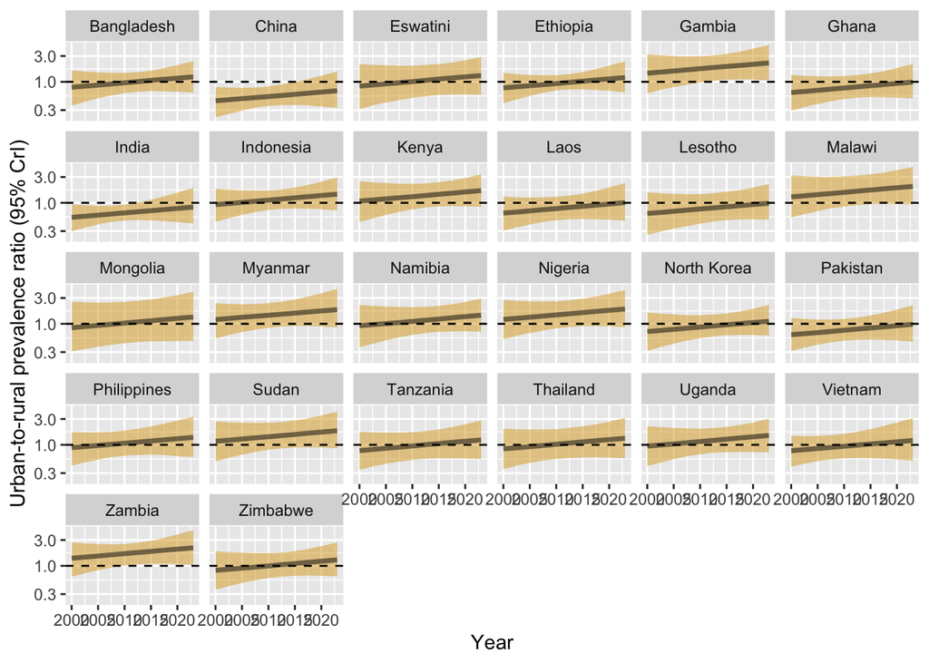

```r
ur_out$ur_draws %>%
  ggplot(aes(x = year_z + 2011, y = urRatio)) +
  stat_lineribbon(.width = 0.95, fill = "goldenrod", alpha = 0.5) +
  geom_hline(yintercept = 1, linetype = 2) +
  scale_y_continuous(
    trans = "log10",
    labels = label_number(accuracy = 0.1),
    breaks = scales::log_breaks()
  ) +
  facet_wrap(~study.country) +
  labs(x = "Year",
       y = "Urban-to-rural prevalence ratio (95% CrI)")
```

```r
ggsave("S6.fig.png", width=10, height=7)
```

2. Organise population denominators

```r
pop_denominators_out <- organise_pop_denominators(modelling_data = bactModelDF,
                                                  population_data = pops,
                                                  urban_data = urban_pop,
                                                  years = c(2000:2023))
```

Plot these out to inspect

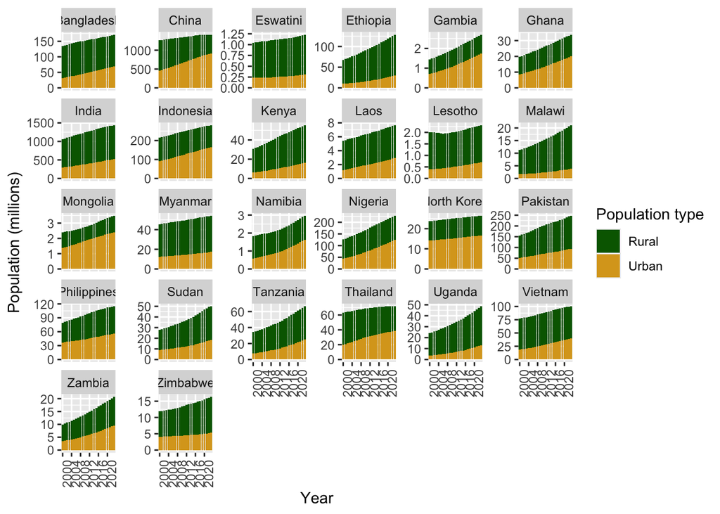

```r
pop_denominators_out %>%
  select(study.country, year, urban_population, rural_population) %>%
  pivot_longer(
    cols = c(urban_population, rural_population),
    names_to = "population_type",
    values_to = "value"
  ) %>%
    mutate(population_type = case_when(
      population_type == "rural_population" ~ "Rural",
      population_type == "urban_population"  ~ "Urban"
    )) %>%
  ggplot(aes(x = factor(year), y = value / 1e6, fill = population_type)) +
    geom_bar(stat = "identity", position = "stack") +
    facet_wrap(~study.country, scales = "free_y") +
    labs(
      x = "Year",
      y = "Population (millions)",
      fill = "Population type"
    ) +
    scale_x_discrete(breaks = function(x) x[seq(1, length(x), by = 4)]) +
    scale_fill_manual(values = c("darkgreen", "goldenrod")) +
    theme(axis.text.x = element_text(angle = 90))
```

```r
ggsave("S7.fig.png", width=10, height=7)
```

3. WHO TB burden data

```r
who_tb_out <- get_who_tb_burden(modelling_data = bactModelDF,
                                who_tb_data = who_tb_burden,
                                years = c(2000:2023))
```

Plot these out to look at them.

Incidence

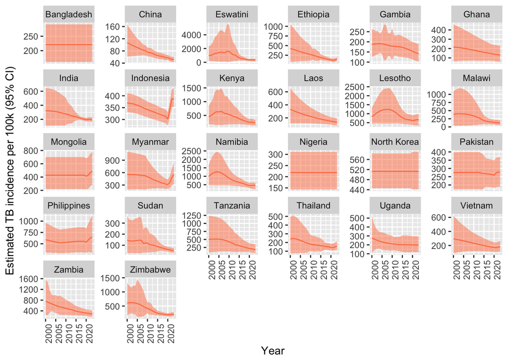

```r
who_tb_out %>%
  ggplot(aes(x=year)) +
  geom_ribbon(aes(ymin = e_inc_100k_lo, ymax = e_inc_100k_hi), alpha = 0.5, fill = "coral") +
  geom_line(aes(y=e_inc_100k), colour = "coral") +
  facet_wrap(~study.country, scales = "free_y")+
  labs(x = "Year",
       y = "Estimated TB incidence per 100k (95% CI)") +
    theme(axis.text.x = element_text(angle = 90))
```

```r
ggsave("S8.fig.png", width=10, height=7)
```

Case detection rate

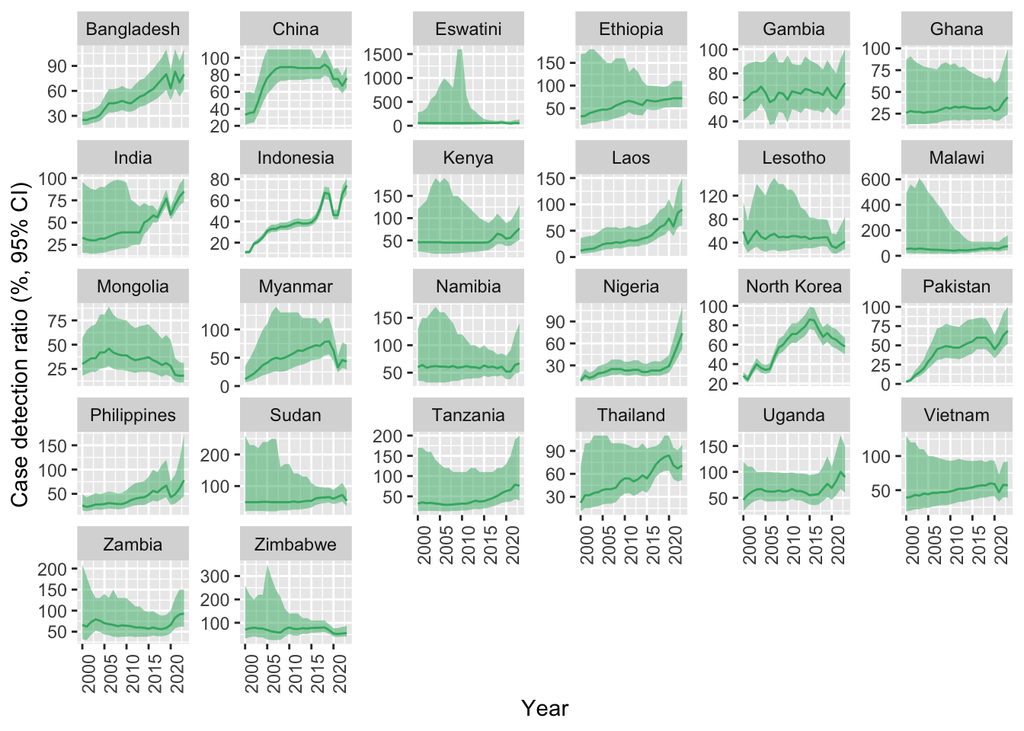

```r
who_tb_out %>%
  ggplot(aes(x=year)) +
  geom_ribbon(aes(ymin = c_cdr_lo, ymax = c_cdr_hi), alpha = 0.5, fill = "mediumseagreen") +
  geom_line(aes(y=c_cdr), colour = "mediumseagreen") +
  labs(x = "Year",
       y = "Case detection ratio (%, 95% CI)") +
  facet_wrap(~study.country, scales = "free_y")+
    theme(axis.text.x = element_text(angle = 90))
```

```r
ggsave("S9.fig.png", width=10, height=7)
```

4. Join the population date to the WHO data

```r
population_and_who_out <- join_population_with_who(population_data = pop_denominators_out,
                                                   who_data = who_tb_out)
```

5. Estimate prevalence of TB by country and year

```r
prevalence_out <- estimate_prevalence(input_data = population_and_who_out,
                                      duration_mode = "mixture",
                                      years = c(2000:2023),
                                      seed = 1234)
```

[output not shown]

[output cut: 123 more lines]

[output not shown]

[output not shown]

[output cut: 123 more lines]

[output not shown]

[output not shown]

[output cut: 123 more lines]

[output not shown]

[output not shown]

[output cut: 123 more lines]

[output not shown]

[output not shown]

[output cut: 123 more lines]

[output not shown]

[output not shown]

[output cut: 123 more lines]

[output not shown]

[output not shown]

[output cut: 123 more lines]

[output not shown]

[output not shown]

[output cut: 123 more lines]

[output not shown]

[output not shown]

[output cut: 123 more lines]

[output not shown]

[output not shown]

[output cut: 123 more lines]

[output not shown]

[output not shown]

[output cut: 123 more lines]

[output not shown]

[output not shown]

[output cut: 123 more lines]

[output not shown]

[output not shown]

[output cut: 123 more lines]

[output not shown]

[output not shown]

[output cut: 123 more lines]

[output not shown]

[output not shown]

[output cut: 123 more lines]

[output not shown]

[output not shown]

[output cut: 123 more lines]

[output not shown]

[output not shown]

[output cut: 123 more lines]

[output not shown]

[output not shown]

[output cut: 123 more lines]

[output not shown]

[output not shown]

[output cut: 123 more lines]

[output not shown]

[output not shown]

[output cut: 123 more lines]

[output not shown]

[output not shown]

[output cut: 123 more lines]

[output not shown]

[output not shown]

[output cut: 123 more lines]

[output not shown]

[output not shown]

[output cut: 123 more lines]

[output not shown]

[output not shown]

[output cut: 123 more lines]

[output not shown]

6. Estimate the numbers of people with prevalent TB

```r
cases_out <- estimate_case_distribution(ur_draws = ur_out$ur_draws,
                                        prev_draws = prevalence_out$mv_draws,
                                        population_data = population_and_who_out)
```

Plot these summarys

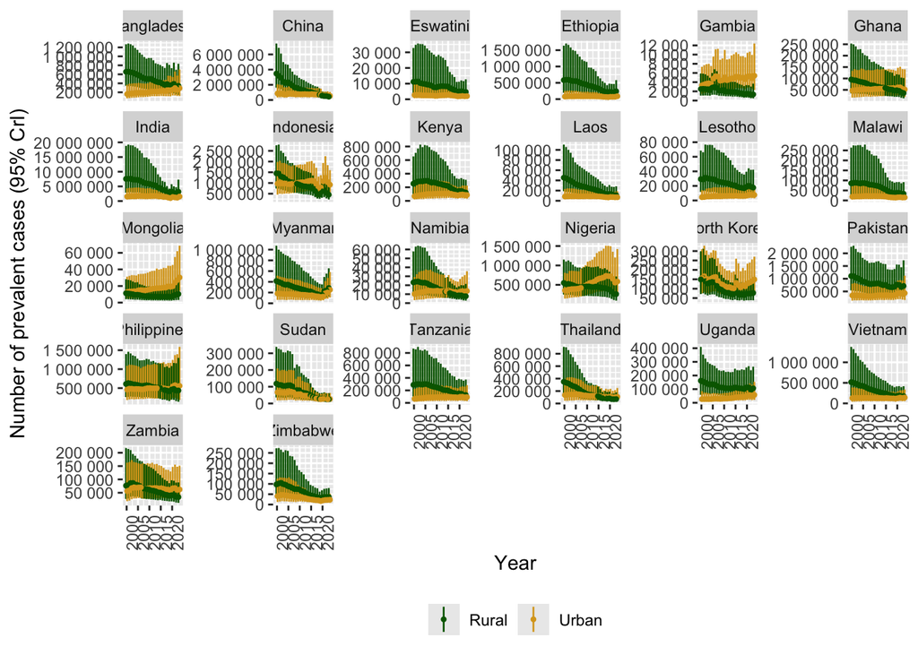

```r
cases_out$cases_draws %>%
  select(study.country, year, cases_u, cases_r) %>%
  pivot_longer(cols = c(cases_u, cases_r)) %>%
  mutate(name = case_when(
    name == "cases_r" ~ "Rural",
    name == "cases_u" ~ "Urban"
  )) %>%
  ggplot() +
    stat_pointinterval(aes(x=year, y=value, colour = name),
    .width = 0.95,
    position = position_dodge(width=1),
    point_size = 0.5,
    size = 0.2) +
  scale_colour_manual(values = c("darkgreen", "goldenrod")) +
  scale_y_continuous(
    labels = label_number(),
    breaks = pretty,
  ) +
    facet_wrap(~study.country, scales = "free_y") +
    labs(x="Year",
         y = "Number of prevalent cases (95% CrI)",
         colour = NULL) +
    theme(legend.position = "bottom",
          axis.text.x = element_text(angle = 90))
```

```r
ggsave("Fig4.png", width=12, height=7)
```

Percentage of urban and rural cases over time

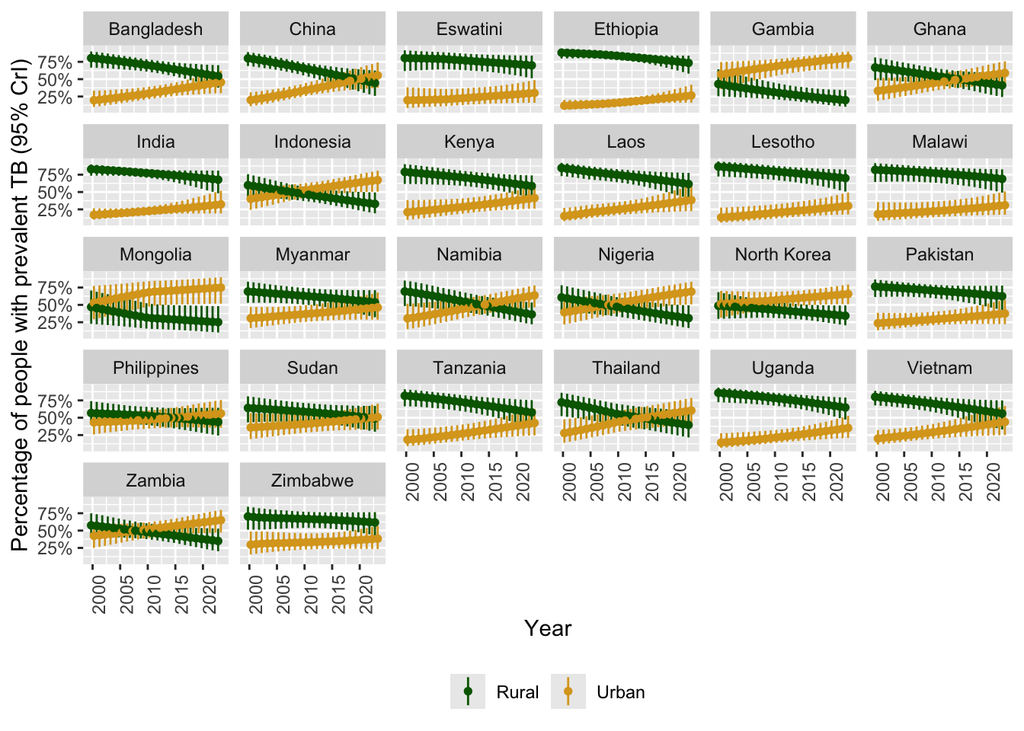

```r
cases_out$cases_draws %>%
  select(study.country, year, perc_u, perc_r) %>%
  pivot_longer(cols = c(perc_u, perc_r)) %>%
  mutate(name = case_when(
    name == "perc_u" ~ "Urban",
    name == "perc_r" ~ "Rural"
  )) %>%
  ggplot() +
    stat_pointinterval(aes(x=year, y=value, colour = name),
    .width = 0.95,
    position = position_dodge(width=1),
    point_size = 1,
    size = 0.3) +
  scale_colour_manual(values = c("darkgreen", "goldenrod")) +
  scale_y_continuous(
    labels = label_percent()
  ) +
    facet_wrap(~study.country) +
    labs(x="Year",
         y = "Percentage of people with prevalent TB (95% CrI)",
         colour = NULL) +
    theme(legend.position = "bottom",
          axis.text.x = element_text(angle = 90))
```

```r
ggsave("S10.fig.png", width=12, height=7)
```

Make a table of estimates for 2023 for presentation in the paper

```r
# 1) Filter posterior draws for 2023
draws_2023 <- cases_out$cases_draws %>%
  filter(year == 2023)

# 2) Compute per-draw totals and percentages for cases
cases_summary <- draws_2023 %>%
  summarise(
    .by = .draw,
    cases_total = sum(cases_total, na.rm = TRUE),
    cases_urban = sum(cases_u, na.rm = TRUE),
    cases_rural = sum(cases_r, na.rm = TRUE),
    n_countries = n_distinct(study.country)
  ) %>%
  mutate(
    perc_urban = cases_urban / cases_total * 100,
    perc_rural = cases_rural / cases_total * 100
  )

# 3) Compute posterior summaries (median + 95% CrI)
cases_summary_stats <- cases_summary %>%
  summarise(
    median_cases_total = median(cases_total),
    lci_cases_total = quantile(cases_total, 0.025),
    uci_cases_total = quantile(cases_total, 0.975),
    median_cases_urban = median(cases_urban),
    lci_cases_urban = quantile(cases_urban, 0.025),
    uci_cases_urban = quantile(cases_urban, 0.975),
    median_cases_rural = median(cases_rural),
    lci_cases_rural = quantile(cases_rural, 0.025),
    uci_cases_rural = quantile(cases_rural, 0.975),
    median_perc_urban = median(perc_urban),
    lci_perc_urban = quantile(perc_urban, 0.025),
    uci_perc_urban = quantile(perc_urban, 0.975),
    median_perc_rural = median(perc_rural),
    lci_perc_rural = quantile(perc_rural, 0.025),
    uci_perc_rural = quantile(perc_rural, 0.975),
    n_countries = median(n_countries)
  )

# 4) Combine with population denominators for 2023
pop_2023 <- pop_denominators_out %>%
  filter(year == 2023) %>%
  summarise(
    total_pop = sum(population),
    urban_pop = sum(urban_population),
    rural_pop = sum(rural_population),
    perc_urban = urban_pop / total_pop * 100,
    perc_rural = rural_pop / total_pop * 100
  )

# 5) Combine into long format for presentation
summary_table_2023 <- tibble(
  metric = c("Total cases", "Urban cases", "Rural cases",
             "Percent urban cases", "Percent rural cases",
             "Total population", "Urban population", "Rural population",
             "Percent urban population", "Percent rural population",
             "Countries represented"),
  median = c(
    cases_summary_stats$median_cases_total,
    cases_summary_stats$median_cases_urban,
    cases_summary_stats$median_cases_rural,
    cases_summary_stats$median_perc_urban,
    cases_summary_stats$median_perc_rural,
    pop_2023$total_pop,
    pop_2023$urban_pop,
    pop_2023$rural_pop,
    pop_2023$perc_urban,
    pop_2023$perc_rural,
    cases_summary_stats$n_countries
  ),
  lci = c(
    cases_summary_stats$lci_cases_total,
    cases_summary_stats$lci_cases_urban,
    cases_summary_stats$lci_cases_rural,
    cases_summary_stats$lci_perc_urban,
    cases_summary_stats$lci_perc_rural,
    NA, NA, NA, NA, NA, NA
  ),
  uci = c(
    cases_summary_stats$uci_cases_total,
    cases_summary_stats$uci_cases_urban,
    cases_summary_stats$uci_cases_rural,
    cases_summary_stats$uci_perc_urban,
    cases_summary_stats$uci_perc_rural,
    NA, NA, NA, NA, NA, NA
  )
) %>%
  # 6) Format numbers nicely
  mutate(
    median_fmt = if_else(str_detect(metric, "Percent"),
                         paste0(round(median, 1), "%"),
                         comma(round(median))),
    ci_fmt = if_else(!is.na(lci),
                     paste0("(", comma(round(lci)), " – ", comma(round(uci)), ")"),
                     NA_character_)
  ) %>%
  select(metric, median = median_fmt, `95% CrI` = ci_fmt)

# 7) Print table
summary_table_2023 %>% datatable()
```

|  | metric | median | 95% CrI |
| --- | --- | --- | --- |
| 1 | Total cases | 13,927,250 | (8,430,505 – 25,372,928) |
| 2 | Urban cases | 6,328,882 | (3,530,284 – 12,151,511) |
| 3 | Rural cases | 7,507,589 | (4,070,782 – 14,664,241) |
| 4 | Percent urban cases | 45.5% | (32 – 62) |
| 5 | Percent rural cases | 54.5% | (38 – 68) |
| 6 | Total population | 4,605,975,853 |  |
| 7 | Urban population | 2,204,169,558 |  |
| 8 | Rural population | 2,401,806,295 |  |
| 9 | Percent urban population | 47.9% |  |
| 10 | Percent rural population | 52.1% |  |

[output cut: 1 more lines]